# final project

Yuchen Zhang

2022-12-12

## Data exploratory

### Distribution of Data

Import data

```r
Body_df = readxl::read_excel("data/body_density_data.xlsx")
tbl_summary(Body_df)
```

| **Characteristic** | **N = 252**<sup>1</sup> |
| --- | --- |
| id | 126 (64, 189) |
| bodyfat_brozek | 19 (13, 25) |
| bodyfat_siri | 19 (12, 25) |
| body_density | 1.055 (1.041, 1.070) |
| age | 43 (36, 54) |
| weight | 176 (159, 197) |
| height | 70.00 (68.25, 72.25) |
| neck | 38.00 (36.40, 39.42) |
| chest | 100 (94, 105) |
| abdomen | 91 (85, 99) |
| hip | 99 (96, 104) |
| thigh | 59.0 (56.0, 62.3) |
| knee | 38.50 (36.98, 39.92) |
| ankle | 22.80 (22.00, 24.00) |
| bicep | 32.05 (30.20, 34.32) |
| forearm | 28.70 (27.30, 30.00) |
| wrist | 18.30 (17.60, 18.80) |

<sup>1</sup> Median (IQR)

```r
summary(Body_df)
```

```
##        id         bodyfat_brozek   bodyfat_siri    body_density
##  Min.   :  1.00   Min.   : 0.00   Min.   : 0.00   Min.   :0.995
##  1st Qu.: 63.75   1st Qu.:12.80   1st Qu.:12.47   1st Qu.:1.041
##  Median :126.50   Median :19.00   Median :19.20   Median :1.055
##  Mean   :126.50   Mean   :18.94   Mean   :19.15   Mean   :1.056
##  3rd Qu.:189.25   3rd Qu.:24.60   3rd Qu.:25.30   3rd Qu.:1.070
##  Max.   :252.00   Max.   :45.10   Max.   :47.50   Max.   :1.109
##       age            weight          height           neck
##  Min.   :22.00   Min.   :118.5   Min.   :64.00   Min.   :31.10
##  1st Qu.:35.75   1st Qu.:159.0   1st Qu.:68.25   1st Qu.:36.40
##  Median :43.00   Median :176.5   Median :70.00   Median :38.00
##  Mean   :44.88   Mean   :178.9   Mean   :70.31   Mean   :37.99
##  3rd Qu.:54.00   3rd Qu.:197.0   3rd Qu.:72.25   3rd Qu.:39.42
##  Max.   :81.00   Max.   :363.1   Max.   :77.75   Max.   :51.20
##      chest           abdomen            hip            thigh
##  Min.   : 79.30   Min.   : 69.40   Min.   : 85.0   Min.   :47.20
##  1st Qu.: 94.35   1st Qu.: 84.58   1st Qu.: 95.5   1st Qu.:56.00
##  Median : 99.65   Median : 90.95   Median : 99.3   Median :59.00
##  Mean   :100.82   Mean   : 92.56   Mean   : 99.9   Mean   :59.41
##  3rd Qu.:105.38   3rd Qu.: 99.33   3rd Qu.:103.5   3rd Qu.:62.35
##  Max.   :136.20   Max.   :148.10   Max.   :147.7   Max.   :87.30
##       knee           ankle          bicep          forearm          wrist
##  Min.   :33.00   Min.   :19.1   Min.   :24.80   Min.   :21.00   Min.   :15.80
##  1st Qu.:36.98   1st Qu.:22.0   1st Qu.:30.20   1st Qu.:27.30   1st Qu.:17.60
##  Median :38.50   Median :22.8   Median :32.05   Median :28.70   Median :18.30
##  Mean   :38.59   Mean   :23.1   Mean   :32.27   Mean   :28.66   Mean   :18.23
##  3rd Qu.:39.92   3rd Qu.:24.0   3rd Qu.:34.33   3rd Qu.:30.00   3rd Qu.:18.80
##  Max.   :49.10   Max.   :33.9   Max.   :45.00   Max.   :34.90   Max.   :21.40
```

We chose fat density of Brozek’s function as outcome and here is the distribution of bodyfat_brozek

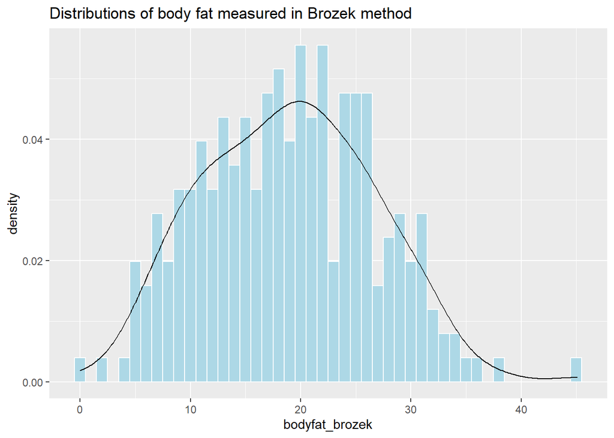

```r
ggplot(Body_df, aes(x = bodyfat_brozek)) +
 geom_histogram(aes(y = ..density..), color = "white", fill = "light blue",binwidth = 1) +
 geom_density(alpha = .2) +
 labs(title = "Distributions of body fat measured in Brozek method")
```

Here are the distribution of all the variables shown in histogram

```r
colnames = colnames(Body_df)
pdf("histogram.pdf")
for (i in 5:17) {
  plot =
ggplot(Body_df, aes_string(x = colnames[i])) +
 geom_histogram(aes(y = ..density..), color = "white", fill = "light blue",binwidth = 1) +
 geom_density(alpha = .2) +
 labs(title = sprintf("Distributions of %s", colnames[i]) )

  print(plot)
}
```

Here are the distribution of all the variables shown in boxplot

```r
colnames = colnames(Body_df)
pdf("boxplot.pdf")
boxplot=
  for (i in 5:17) {
  plot =
ggplot(Body_df, aes_string(y = colnames[i])) +
 geom_boxplot() +
 labs(title = sprintf("Distributions of %s", colnames[i]) )

  print(plot)
}
```

From the distribution plots of the variables, we can find that, all the variables are in normal distribution with very few outliers. Thus, no transformation is required. There is a sample in which body fat calculated with Brozek’s equation is 0 percent, which is abnormal, so we eliminate this point. Since our sample size is small, we won’t do any further research to remove other abnormal data points that are not so obvious.

Here, we clean the data

```r
bodyfat_selected =
  Body_df %>%
  dplyr::select(-id,-bodyfat_siri,-body_density) %>%
  filter(bodyfat_brozek > 0)
```

Here are the correlation between the bodyfat_brozek with the predictors

```r
# Building scatter plots
pdf("correlation.pdf")
correlation =
for (i in 5:17) {
  plot =
  Body_df %>%
    ggplot(aes_string(x = colnames[i], y = "bodyfat_brozek")) + geom_point() + geom_smooth(method = 'lm', se = TRUE, color = 'red') +
    labs(title = sprintf("Scatter plot for body fat against %s", colnames[i]) ) +
    ylab("Body Fat (Brozek)")

  print(plot)
}
```

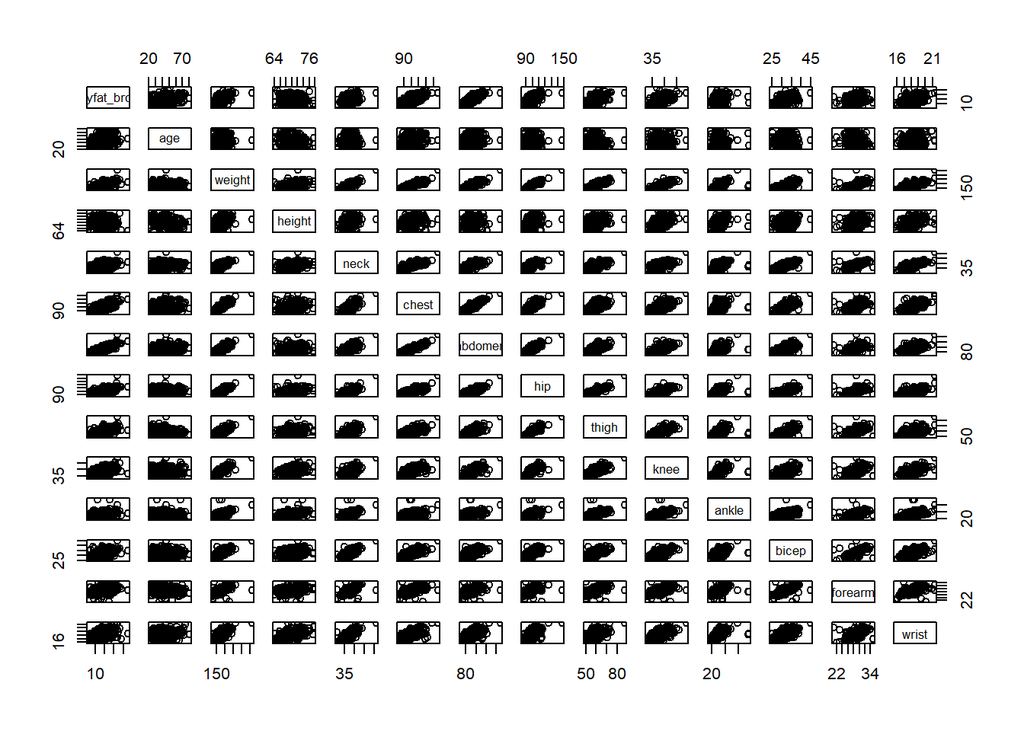

```r
# Pair the variables
pair = pairs(bodyfat_selected)
```

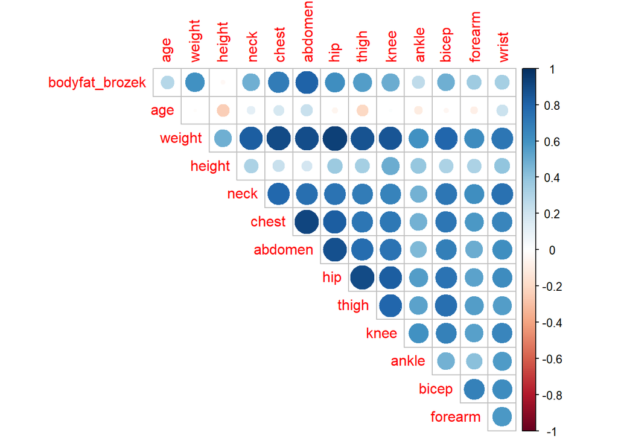

```r
# Corrplot the variables
corplot = corrplot(cor(bodyfat_selected), type = "upper", diag = FALSE)
```

We can find that, most of the variables have linear correlation with others. It should be paid attention in later data analysis.

## Building models

All the variables are normally distributed and required no transformation. As the outcome and predictors are all quantitative data, it would be improper to fit the model in Logistic Regression or exponential regression. Thus linear regression may be still the best choice for use to build the model.

Let’s firstly build fit all the variables in a Multiple linear regression model.

```r
multifit = lm(bodyfat_brozek ~ ., data = bodyfat_selected)
```

### Linear Regression

#### Automatic Selection

Backward Elmination

```r
step(multifit, direction = "backward")
```

```
## Start:  AIC=707.65
## bodyfat_brozek ~ age + weight + height + neck + chest + abdomen +
##     hip + thigh + knee + ankle + bicep + forearm + wrist
##
##           Df Sum of Sq    RSS    AIC
## - knee     1      0.05 3764.0 705.66
## - height   1      1.79 3765.8 705.77
## - chest    1      2.04 3766.0 705.79
## - ankle    1      9.00 3773.0 706.25
## - bicep    1     17.07 3781.1 706.79
## - hip      1     30.04 3794.0 707.65
## <none>                 3764.0 707.65
## - weight   1     30.99 3795.0 707.71
## - thigh    1     42.91 3806.9 708.50
## - age      1     60.20 3824.2 709.64
## - neck     1     64.55 3828.5 709.92
## - forearm  1     82.23 3846.2 711.08
## - wrist    1    151.88 3915.9 715.58
## - abdomen  1   1794.96 5558.9 803.53
##
## Step:  AIC=705.66
## bodyfat_brozek ~ age + weight + height + neck + chest + abdomen +
##     hip + thigh + ankle + bicep + forearm + wrist
##
##           Df Sum of Sq    RSS    AIC
## - chest    1      2.02 3766.1 703.79
## - height   1      2.04 3766.1 703.79
## - ankle    1      9.04 3773.1 704.26
## - bicep    1     17.21 3781.2 704.80
## <none>                 3764.0 705.66
## - hip      1     30.37 3794.4 705.67
## - weight   1     31.61 3795.6 705.76
## - thigh    1     46.33 3810.4 706.73
## - age      1     63.36 3827.4 707.85
## - neck     1     64.94 3829.0 707.95
## - forearm  1     82.45 3846.5 709.09
## - wrist    1    153.16 3917.2 713.67
## - abdomen  1   1795.12 5559.2 801.53
##
## Step:  AIC=703.79
```

[output cut: 49 more lines]

```
##
## Step:  AIC=699.66
## bodyfat_brozek ~ age + weight + neck + abdomen + hip + thigh +
##     forearm + wrist
##
##           Df Sum of Sq    RSS    AIC
## <none>                 3794.3 699.66
## - hip      1     32.77 3827.1 699.82
## - neck     1     65.39 3859.7 701.95
## - age      1     65.69 3860.0 701.97
## - weight   1     78.60 3872.9 702.81
## - thigh    1     82.85 3877.1 703.09
## - forearm  1    116.31 3910.6 705.24
## - wrist    1    143.34 3937.6 706.97
## - abdomen  1   2705.26 6499.5 832.76
```

```
##
## Call:
## lm(formula = bodyfat_brozek ~ age + weight + neck + abdomen +
##     hip + thigh + forearm + wrist, data = bodyfat_selected)
##
## Coefficients:
## (Intercept)          age       weight         neck      abdomen          hip
##   -19.00338      0.05827     -0.08266     -0.42436      0.87429     -0.18514
##       thigh      forearm        wrist
##     0.27507      0.47002     -1.42508
```

The Final model obtained from Backward Elimination is **lm(formula = bodyfat_brozek ~ age + weight + neck + abdomen + hip + thigh + forearm + wrist, data = bodyfat_selected)**

Forward selection

```r
intercept_only = lm(bodyfat_brozek ~ 1, data = bodyfat_selected)
step(intercept_only, direction = "forward", scope = formula(multifit))
```

```
## Start:  AIC=1023.93
## bodyfat_brozek ~ 1
##
##           Df Sum of Sq     RSS     AIC
## + abdomen  1    9653.8  5065.2  758.18
## + chest    1    7115.7  7603.2  860.13
## + hip      1    5623.3  9095.6  905.11
## + weight   1    5394.8  9324.1  911.34
## + thigh    1    4470.3 10248.6  935.07
## + knee     1    3643.5 11075.4  954.54
## + bicep    1    3480.6 11238.3  958.21
## + neck     1    3437.9 11281.1  959.16
## + forearm  1    1809.7 12909.2  993.00
## + wrist    1    1659.6 13059.4  995.90
## + age      1    1228.8 13490.1 1004.05
## + ankle    1     954.0 13764.9 1009.11
## <none>                 14718.9 1023.93
## + height   1      16.6 14702.3 1025.65
##
## Step:  AIC=758.18
## bodyfat_brozek ~ abdomen
##
##           Df Sum of Sq    RSS    AIC
## + weight   1    860.58 4204.6 713.44
## + wrist    1    614.47 4450.7 727.72
## + neck     1    523.82 4541.3 732.78
## + height   1    508.94 4556.2 733.60
## + hip      1    474.10 4591.1 735.51
## + knee     1    289.81 4775.4 745.39
## + ankle    1    206.25 4858.9 749.74
## + chest    1    182.56 4882.6 750.96
## + age      1    165.66 4899.5 751.83
## + thigh    1    152.60 4912.6 752.50
## + bicep    1    118.06 4947.1 754.26
## + forearm  1     48.54 5016.6 757.76
## <none>                 5065.2 758.18
##
## Step:  AIC=713.44
## bodyfat_brozek ~ abdomen + weight
##
```

[output cut: 82 more lines]

```
## + knee    1     3.516 3837.1 702.48
## + chest   1     3.193 3837.4 702.50
## + height  1     2.751 3837.8 702.53
##
## Step:  AIC=700.41
## bodyfat_brozek ~ abdomen + weight + wrist + forearm + neck +
##     bicep + age + thigh
##
##          Df Sum of Sq    RSS    AIC
## <none>                3805.6 700.41
## + hip     1   28.5999 3777.0 700.52
## + ankle   1   11.0547 3794.5 701.68
## + height  1    0.1318 3805.5 702.40
## + chest   1    0.1129 3805.5 702.40
## + knee    1    0.0066 3805.6 702.41
```

```
##
## Call:
## lm(formula = bodyfat_brozek ~ abdomen + weight + wrist + forearm +
##     neck + bicep + age + thigh, data = bodyfat_selected)
##
## Coefficients:
## (Intercept)      abdomen       weight        wrist      forearm         neck
##   -28.94511      0.85489     -0.11737     -1.42807      0.43701     -0.39574
##       bicep          age        thigh
##     0.18172      0.05799      0.16588
```

The model obtained from Forward Selection is **lm(formula = bodyfat_brozek ~ abdomen + weight + wrist + forearm + neck + bicep + age + thigh, data = bodyfat_selected)**

Stepwise Selection

```r
step(multifit, direction = "both")
```

```
## Start:  AIC=707.65
## bodyfat_brozek ~ age + weight + height + neck + chest + abdomen +
##     hip + thigh + knee + ankle + bicep + forearm + wrist
##
##           Df Sum of Sq    RSS    AIC
## - knee     1      0.05 3764.0 705.66
## - height   1      1.79 3765.8 705.77
## - chest    1      2.04 3766.0 705.79
## - ankle    1      9.00 3773.0 706.25
## - bicep    1     17.07 3781.1 706.79
## - hip      1     30.04 3794.0 707.65
## <none>                 3764.0 707.65
## - weight   1     30.99 3795.0 707.71
## - thigh    1     42.91 3806.9 708.50
## - age      1     60.20 3824.2 709.64
## - neck     1     64.55 3828.5 709.92
## - forearm  1     82.23 3846.2 711.08
## - wrist    1    151.88 3915.9 715.58
## - abdomen  1   1794.96 5558.9 803.53
##
## Step:  AIC=705.66
## bodyfat_brozek ~ age + weight + height + neck + chest + abdomen +
##     hip + thigh + ankle + bicep + forearm + wrist
##
##           Df Sum of Sq    RSS    AIC
## - chest    1      2.02 3766.1 703.79
## - height   1      2.04 3766.1 703.79
## - ankle    1      9.04 3773.1 704.26
## - bicep    1     17.21 3781.2 704.80
## <none>                 3764.0 705.66
## - hip      1     30.37 3794.4 705.67
## - weight   1     31.61 3795.6 705.76
## - thigh    1     46.33 3810.4 706.73
## + knee     1      0.05 3764.0 707.65
## - age      1     63.36 3827.4 707.85
## - neck     1     64.94 3829.0 707.95
## - forearm  1     82.45 3846.5 709.09
## - wrist    1    153.16 3917.2 713.67
## - abdomen  1   1795.12 5559.2 801.53
##
```

[output cut: 64 more lines]

```
##           Df Sum of Sq    RSS    AIC
## <none>                 3794.3 699.66
## - hip      1     32.77 3827.1 699.82
## + bicep    1     17.28 3777.0 700.52
## + ankle    1      8.72 3785.6 701.09
## + height   1      3.34 3790.9 701.44
## + chest    1      0.37 3793.9 701.64
## + knee     1      0.10 3794.2 701.66
## - neck     1     65.39 3859.7 701.95
## - age      1     65.69 3860.0 701.97
## - weight   1     78.60 3872.9 702.81
## - thigh    1     82.85 3877.1 703.09
## - forearm  1    116.31 3910.6 705.24
## - wrist    1    143.34 3937.6 706.97
## - abdomen  1   2705.26 6499.5 832.76
```

```
##
## Call:
## lm(formula = bodyfat_brozek ~ age + weight + neck + abdomen +
##     hip + thigh + forearm + wrist, data = bodyfat_selected)
##
## Coefficients:
## (Intercept)          age       weight         neck      abdomen          hip
##   -19.00338      0.05827     -0.08266     -0.42436      0.87429     -0.18514
##       thigh      forearm        wrist
##     0.27507      0.47002     -1.42508
```

The stepwise selection from both side get us the model to be **lm(formula = bodyfat_brozek ~ age + weight + neck + abdomen + hip + thigh + forearm + wrist, data = bodyfat_selected)**

Model validation

```r
set.seed(1)
train = trainControl(method = "cv", number = 5)
model_for = train(bodyfat_brozek ~ age + weight + neck + abdomen + hip + thigh + bicep + forearm + wrist, data = bodyfat_selected,
                    trControl = train,
                    method = "lm",
                    na.action = na.pass)

model_for$finalModel
```

```
##
## Call:
## lm(formula = .outcome ~ ., data = dat)
##
## Coefficients:
## (Intercept)          age       weight         neck      abdomen          hip
##   -19.54727      0.05613     -0.09044     -0.44847      0.87823     -0.17358
##       thigh        bicep      forearm        wrist
##     0.24067      0.16368      0.41066     -1.43100
```

```r
model_back = train(bodyfat_brozek ~ age + weight + neck + abdomen + hip + thigh + forearm + wrist,
                    data = bodyfat_selected,
                    trControl = train,
                    method = "lm",
                    na.action = na.pass)

model_back$finalModel
```

```
##
## Call:
## lm(formula = .outcome ~ ., data = dat)
##
## Coefficients:
## (Intercept)          age       weight         neck      abdomen          hip
##   -19.00338      0.05827     -0.08266     -0.42436      0.87429     -0.18514
##       thigh      forearm        wrist
##     0.27507      0.47002     -1.42508
```

```r
print(model_for)
```

```
## Linear Regression
##
## 251 samples
##   9 predictor
##
## No pre-processing
## Resampling: Cross-Validated (5 fold)
## Summary of sample sizes: 201, 202, 202, 199, 200
## Resampling results:
##
##   RMSE     Rsquared   MAE
##   4.02546  0.7292992  3.286613
##
## Tuning parameter 'intercept' was held constant at a value of TRUE
```

```r
print(model_back)
```

```
## Linear Regression
##
## 251 samples
##   8 predictor
##
## No pre-processing
## Resampling: Cross-Validated (5 fold)
## Summary of sample sizes: 199, 201, 201, 200, 203
## Resampling results:
##
##   RMSE      Rsquared   MAE
##   4.074935  0.7302663  3.330233
##
## Tuning parameter 'intercept' was held constant at a value of TRUE
```

The RMSE of model_for(4.025) is slightly smaller than that of model_back(4.075). Model_for is more preferred. However, considering the principle of parsimony, we will run ANOVA to further compare the two models.

```r
model_for = lm(bodyfat_brozek ~ age + weight + neck + abdomen + hip + thigh + bicep + forearm + wrist, data = bodyfat_selected)

model_back = lm(bodyfat_brozek ~ age + weight + neck + abdomen + hip + thigh + forearm + wrist, data = bodyfat_selected)
anova(model_back, model_for)
```

```
## Analysis of Variance Table
##
## Model 1: bodyfat_brozek ~ age + weight + neck + abdomen + hip + thigh +
##     forearm + wrist
## Model 2: bodyfat_brozek ~ age + weight + neck + abdomen + hip + thigh +
##     bicep + forearm + wrist
##   Res.Df    RSS Df Sum of Sq      F Pr(>F)
## 1    242 3794.3
## 2    241 3777.0  1    17.284 1.1028 0.2947
```

From the procedures we done above, the final model was agreed to be **lm(formula = bodyfat_brozek ~ age + weight + neck + abdomen + hip + thigh + forearm + wrist, data = bodyfat_selected)**

#### Test Based Procedures

Then, let’s try Tested Based Procedures “Cp test”

```r
mat = as.matrix(bodyfat_selected)
leaps(x = mat[,2:14], y = mat[,1], nbest = 2, method = "Cp")
```

```
## $which
##        1     2     3     4     5     6     7     8     9     A     B     C
## 1  FALSE FALSE FALSE FALSE FALSE  TRUE FALSE FALSE FALSE FALSE FALSE FALSE
## 1  FALSE FALSE FALSE FALSE  TRUE FALSE FALSE FALSE FALSE FALSE FALSE FALSE
## 2  FALSE  TRUE FALSE FALSE FALSE  TRUE FALSE FALSE FALSE FALSE FALSE FALSE
## 2  FALSE FALSE FALSE FALSE FALSE  TRUE FALSE FALSE FALSE FALSE FALSE FALSE
## 3  FALSE  TRUE FALSE FALSE FALSE  TRUE FALSE FALSE FALSE FALSE FALSE FALSE
## 3  FALSE  TRUE FALSE  TRUE FALSE  TRUE FALSE FALSE FALSE FALSE FALSE FALSE
## 4  FALSE  TRUE FALSE FALSE FALSE  TRUE FALSE FALSE FALSE FALSE FALSE  TRUE
## 4  FALSE  TRUE FALSE FALSE FALSE  TRUE FALSE FALSE FALSE FALSE  TRUE FALSE
## 5  FALSE  TRUE FALSE  TRUE FALSE  TRUE FALSE FALSE FALSE FALSE FALSE  TRUE
## 5   TRUE  TRUE FALSE FALSE FALSE  TRUE FALSE FALSE FALSE FALSE FALSE  TRUE
## 6   TRUE  TRUE FALSE FALSE FALSE  TRUE FALSE  TRUE FALSE FALSE FALSE  TRUE
## 6  FALSE  TRUE FALSE  TRUE FALSE  TRUE FALSE FALSE FALSE FALSE  TRUE  TRUE
## 7   TRUE  TRUE FALSE  TRUE FALSE  TRUE FALSE  TRUE FALSE FALSE FALSE  TRUE
```

[output cut: 53 more lines]

The smallest Cp value we got indicate that best model: **lm(formula = bodyfat_brozek ~ age + weight + neck + abdomen + hip + thigh + forearm + wrist, data = bodyfat_selected)**

```r
leaps(x = mat[,2:14], y = mat[,1], nbest = 2, method = "adjr2")
```

```
## $which
##        1     2     3     4     5     6     7     8     9     A     B     C
## 1  FALSE FALSE FALSE FALSE FALSE  TRUE FALSE FALSE FALSE FALSE FALSE FALSE
## 1  FALSE FALSE FALSE FALSE  TRUE FALSE FALSE FALSE FALSE FALSE FALSE FALSE
## 2  FALSE  TRUE FALSE FALSE FALSE  TRUE FALSE FALSE FALSE FALSE FALSE FALSE
## 2  FALSE FALSE FALSE FALSE FALSE  TRUE FALSE FALSE FALSE FALSE FALSE FALSE
## 3  FALSE  TRUE FALSE FALSE FALSE  TRUE FALSE FALSE FALSE FALSE FALSE FALSE
## 3  FALSE  TRUE FALSE  TRUE FALSE  TRUE FALSE FALSE FALSE FALSE FALSE FALSE
## 4  FALSE  TRUE FALSE FALSE FALSE  TRUE FALSE FALSE FALSE FALSE FALSE  TRUE
## 4  FALSE  TRUE FALSE FALSE FALSE  TRUE FALSE FALSE FALSE FALSE  TRUE FALSE
## 5  FALSE  TRUE FALSE  TRUE FALSE  TRUE FALSE FALSE FALSE FALSE FALSE  TRUE
## 5   TRUE  TRUE FALSE FALSE FALSE  TRUE FALSE FALSE FALSE FALSE FALSE  TRUE
## 6   TRUE  TRUE FALSE FALSE FALSE  TRUE FALSE  TRUE FALSE FALSE FALSE  TRUE
## 6  FALSE  TRUE FALSE  TRUE FALSE  TRUE FALSE FALSE FALSE FALSE  TRUE  TRUE
## 7   TRUE  TRUE FALSE  TRUE FALSE  TRUE FALSE  TRUE FALSE FALSE FALSE  TRUE
```

[output cut: 52 more lines]

The largest adjusted R2 indicated the best subset to be: **lm(formula = bodyfat_brozek ~ age + weight + neck + abdomen + hip + thigh + bicep + forearm + wrist, data= bodyfat_selected)**

The model obtained by the via Mallow’s Cp and Ajusted R squares are slightly different. As the models obtained are the identical as what we obtained in Automatic selection, same result can be obtained via model validation.

The model we chosen would be **lm(formula = bodyfat_brozek ~ age + weight + neck + abdomen + hip + thigh + forearm + wrist, data = bodyfat_selected)**

#### LASSO

Let’s use corss validation to choose lambda

```r
lambda_seq = 10^seq(-3, 0, by = 0.1)
set.seed(1)
cv_bodyfat = cv.glmnet(as.matrix(bodyfat_selected[2:14]), bodyfat_selected$bodyfat_brozek, lambda = lambda_seq, nfolds = 5)
cv_bodyfat
```

```
##
## Call:  cv.glmnet(x = as.matrix(bodyfat_selected[2:14]), y = bodyfat_selected$bodyfat_brozek,      lambda = lambda_seq, nfolds = 5)
##
## Measure: Mean-Squared Error
##
##      Lambda Index Measure     SE Nonzero
## min 0.01585    19   16.83 0.8678      12
## 1se 0.19953     8   17.64 0.9817       6
```

```r
lasso_fit = glmnet::glmnet(as.matrix(bodyfat_selected[2:14]), bodyfat_selected$bodyfat_brozek, lambda = cv_bodyfat$lambda.min)
coef(lasso_fit)
```

```
## 14 x 1 sparse Matrix of class "dgCMatrix"
##                       s0
## (Intercept) -11.79379143
## age           0.05677414
## weight       -0.06785393
## height       -0.08715773
## neck         -0.42814041
## chest        -0.02161955
## abdomen       0.85241509
## hip          -0.16240545
## thigh         0.18984863
## knee          .
## ankle         0.11205159
## bicep         0.14002270
## forearm       0.39704078
## wrist        -1.50944944
```

The final model obtained from LASSO is **lm(formula =bodyfat_brozek ~ age + weight + height + neck + chest + abdomen + hip + thigh + ankle + bicep + forearm + wrist, data = bodyfat_selected)**

### Model choose

Stepwise selection and criterion test both indicate the same model. The LASSO model includes more predictors. Further process would be done to choose from the LASSO model: **lm(formula =bodyfat_brozek ~ age + weight + height + neck + chest + abdomen + hip + thigh + ankle + bicep + forearm + wrist, data = bodyfat_selected)** and the small model **lm(formula = bodyfat_brozek ~ age + weight + neck + abdomen + hip + thigh + forearm + wrist, data= bodyfat_selected)**.

#### Model Validation

Since the lasso method incurs a different model, so we will adopt model validation to choose the better model. First, use 5-fold validation and create the training sets.

```r
train = trainControl(method = "cv", number = 5)
```

Then, fit the lasso model.

```r
set.seed(1)
model_lasso = train(bodyfat_brozek ~ age + weight + height + neck + chest + abdomen + hip + thigh + ankle + bicep + forearm + wrist,
                    data = bodyfat_selected,
                    trControl = train,
                    method = "lm",
                    na.action = na.pass)

model_lasso$finalModel
```

```
##
## Call:
## lm(formula = .outcome ~ ., data = dat)
##
## Coefficients:
## (Intercept)          age       weight       height         neck        chest
##   -14.80034      0.05754     -0.08070     -0.05792     -0.43777     -0.03440
##     abdomen          hip        thigh        ankle        bicep      forearm
##     0.88644     -0.18474      0.22114      0.15289      0.16610      0.41913
##       wrist
##    -1.52734
```

```r
model_test = train(bodyfat_brozek ~ age + weight + neck + abdomen + hip + thigh + forearm + wrist,
                    data = bodyfat_selected,
                    trControl = train,
                    method = "lm",
                    na.action = na.pass)

model_test$finalModel
```

```
##
## Call:
## lm(formula = .outcome ~ ., data = dat)
##
## Coefficients:
## (Intercept)          age       weight         neck      abdomen          hip
##   -19.00338      0.05827     -0.08266     -0.42436      0.87429     -0.18514
##       thigh      forearm        wrist
##     0.27507      0.47002     -1.42508
```

```r
print(model_lasso)
```

```
## Linear Regression
##
## 251 samples
##  12 predictor
##
## No pre-processing
## Resampling: Cross-Validated (5 fold)
## Summary of sample sizes: 201, 202, 202, 199, 200
## Resampling results:
##
##   RMSE     Rsquared   MAE
##   4.18458  0.7113264  3.39777
##
## Tuning parameter 'intercept' was held constant at a value of TRUE
```

```r
print(model_test)
```

```
## Linear Regression
##
## 251 samples
##   8 predictor
##
## No pre-processing
## Resampling: Cross-Validated (5 fold)
## Summary of sample sizes: 199, 201, 201, 200, 203
## Resampling results:
##
##   RMSE      Rsquared   MAE
##   4.074935  0.7302663  3.330233
##
## Tuning parameter 'intercept' was held constant at a value of TRUE
```

The RMSE obtained from model_lasso is 4.1846 and that of model_test is 4.0749. The MAE obtained from model_lasso is 3.397 and that of model_test is 3.330.

As the RMSE and MAE are slightly smaller in tested model, it is more preferred. However, considering the principle of parsimony, we will run ANOVA to further compare the two models.

#### ANOVA for MLR

```r
model_small = lm(bodyfat_brozek ~ age + weight + neck + abdomen + hip + thigh + forearm + wrist,
                    data = bodyfat_selected)
model_large = lm(bodyfat_brozek ~ age + weight + height + neck + chest + abdomen + hip + thigh + ankle + bicep + forearm + wrist, data = bodyfat_selected)

anova(model_small,model_large)
```

```
## Analysis of Variance Table
##
## Model 1: bodyfat_brozek ~ age + weight + neck + abdomen + hip + thigh +
##     forearm + wrist
## Model 2: bodyfat_brozek ~ age + weight + height + neck + chest + abdomen +
##     hip + thigh + ankle + bicep + forearm + wrist
##   Res.Df    RSS Df Sum of Sq      F Pr(>F)
## 1    242 3794.3
## 2    238 3764.0  4    30.243 0.4781 0.7518
```

F = 0.4781, p_value = 0.7518, we fail to reject H0 and conclude that the larger model is not superior. Now, according to the principle of parsimony, we will choose the small model.

```r
model_1 = model_small
summary(model_1)
```

```
##
## Call:
## lm(formula = bodyfat_brozek ~ age + weight + neck + abdomen +
##     hip + thigh + forearm + wrist, data = bodyfat_selected)
##
## Residuals:
##     Min      1Q  Median      3Q     Max
## -10.117  -2.800  -0.223   2.709   9.477
##
## Coefficients:
##              Estimate Std. Error t value Pr(>|t|)
## (Intercept) -19.00338   10.86380  -1.749  0.08152 .
## age           0.05827    0.02847   2.047  0.04175 *
## weight       -0.08266    0.03692  -2.239  0.02607 *
## neck         -0.42436    0.20780  -2.042  0.04222 *
## abdomen       0.87429    0.06656  13.136  < 2e-16 ***
## hip          -0.18514    0.12805  -1.446  0.14952
## thigh         0.27507    0.11966   2.299  0.02237 *
## forearm       0.47002    0.17257   2.724  0.00693 **
## wrist        -1.42508    0.47132  -3.024  0.00277 **
## ---
## Signif. codes:  0 '***' 0.001 '**' 0.01 '*' 0.05 '.' 0.1 ' ' 1
##
## Residual standard error: 3.96 on 242 degrees of freedom
## Multiple R-squared:  0.7422, Adjusted R-squared:  0.7337
## F-statistic:  87.1 on 8 and 242 DF,  p-value: < 2.2e-16
```

## Interaction

In the data exploration part, we found that the correlation between the variables are very significant. The predictors can interact with each other. Thus, let’s check it again with our further selected data.

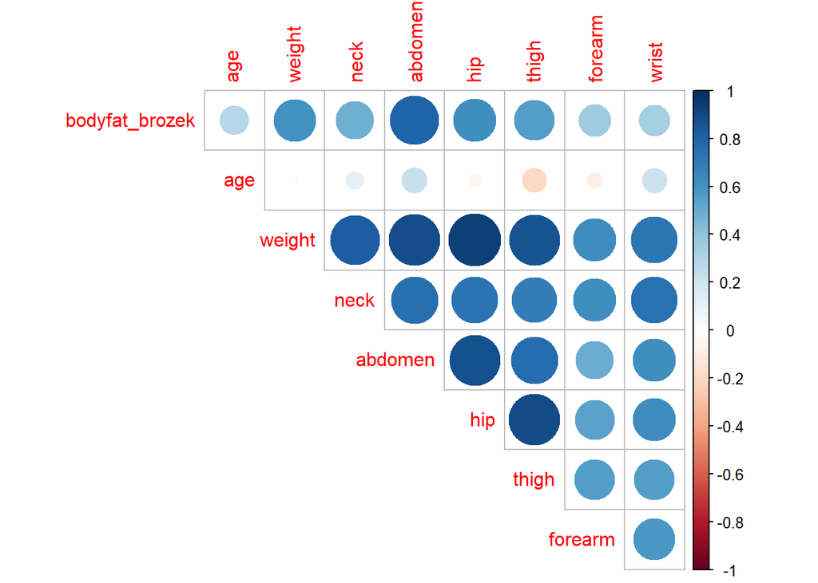

```r
body_mod_select = bodyfat_selected %>%
  dplyr::select(bodyfat_brozek, age, weight, neck, abdomen, hip, thigh, forearm, wrist)
corrplot(cor(body_mod_select), type = "upper", diag = FALSE)
```

We can find that the correlation of the variables left are strong between each other, except age. Let’s check their interactions.

```r
lm.fit2 = lm(bodyfat_brozek ~ (age + weight + neck + abdomen + hip + thigh + forearm + wrist)^2,
             data = bodyfat_selected)
table = anova(lm.fit2)

inter_group = table %>%
  filter(`Pr(>F)` < 0.05)

inter_group
```

```
## Analysis of Variance Table
##
## Response: bodyfat_brozek
##              Df Sum Sq Mean Sq  F value    Pr(>F)
## age           1 1228.8  1228.8  81.1709 < 2.2e-16 ***
## weight        1 5479.4  5479.4 361.9375 < 2.2e-16 ***
## neck          1  152.5   152.5  10.0751  0.001724 **
## abdomen       1 3727.0  3727.0 246.1871 < 2.2e-16 ***
## thigh         1  112.3   112.3   7.4149  0.007002 **
## forearm       1   74.3    74.3   4.9073  0.027798 *
## wrist         1  143.3   143.3   9.4682  0.002364 **
## weight:neck   1  110.8   110.8   7.3156  0.007386 **
## neck:abdomen  1   62.2    62.2   4.1114  0.043834 *
## ---
## Signif. codes:  0 '***' 0.001 '**' 0.01 '*' 0.05 '.' 0.1 ' ' 1
```

From the table, based on the pvalue smaller than 0.05. We found that only the weight:neck and neck: abdomen’s interaction are statistically significant. Thus, these two interactive groups would be included in the model.

The model with interaction between significant associated predictors is: **model_2 = lm(bodyfat_brozek ~ age + weight + neck + abdomen + hip + thigh + forearm + wrist + weight:neck + neck:abdomen, data = bodyfat_selected)**

```r
model_2 = lm(bodyfat_brozek ~ age + weight + neck + abdomen + hip + thigh + forearm + wrist + weight*neck + neck*abdomen, data = bodyfat_selected)
summary(model_2)
```

```
##
## Call:
## lm(formula = bodyfat_brozek ~ age + weight + neck + abdomen +
##     hip + thigh + forearm + wrist + weight * neck + neck * abdomen,
##     data = bodyfat_selected)
##
## Residuals:
##     Min      1Q  Median      3Q     Max
## -9.2337 -2.5363 -0.2964  2.7402  9.3143
##
## Coefficients:
##               Estimate Std. Error t value Pr(>|t|)
## (Intercept)  13.845207  39.141311   0.354 0.723857
## age           0.065526   0.028145   2.328 0.020735 *
## weight        0.641405   0.306566   2.092 0.037469 *
## neck         -1.155900   1.004728  -1.150 0.251099
## abdomen      -0.860353   0.957353  -0.899 0.369724
## hip          -0.150543   0.127789  -1.178 0.239941
## thigh         0.271825   0.120088   2.264 0.024496 *
## forearm       0.292488   0.181441   1.612 0.108270
## wrist        -1.607618   0.467833  -3.436 0.000695 ***
## weight:neck  -0.018230   0.007826  -2.329 0.020678 *
## neck:abdomen  0.044050   0.024734   1.781 0.076179 .
## ---
## Signif. codes:  0 '***' 0.001 '**' 0.01 '*' 0.05 '.' 0.1 ' ' 1
##
## Residual standard error: 3.898 on 240 degrees of freedom
## Multiple R-squared:  0.7522, Adjusted R-squared:  0.7419
## F-statistic: 72.86 on 10 and 240 DF,  p-value: < 2.2e-16
```

```r
broom::tidy(summary(model_2))
```

```
## # A tibble: 11 × 5
##    term         estimate std.error statistic  p.value
##    <chr>           <dbl>     <dbl>     <dbl>    <dbl>
##  1 (Intercept)   13.8     39.1         0.354 0.724
##  2 age            0.0655   0.0281      2.33  0.0207
##  3 weight         0.641    0.307       2.09  0.0375
##  4 neck          -1.16     1.00       -1.15  0.251
##  5 abdomen       -0.860    0.957      -0.899 0.370
##  6 hip           -0.151    0.128      -1.18  0.240
##  7 thigh          0.272    0.120       2.26  0.0245
##  8 forearm        0.292    0.181       1.61  0.108
##  9 wrist         -1.61     0.468      -3.44  0.000695
## 10 weight:neck   -0.0182   0.00783    -2.33  0.0207
## 11 neck:abdomen   0.0441   0.0247      1.78  0.0762
```

Here, we got two candidate model. One without interactions: **model_1 = lm(bodyfat_brozek ~ age + weight + neck + abdomen + hip + thigh + forearm + wrist, data = bodyfat_selected)**

Another one with interactions: **model_2 = lm(bodyfat_brozek ~ age + weight + neck + abdomen + hip + thigh + forearm + wrist + weight:neck + neck:abdomen, data = bodyfat_selected)**

## Model Diagnostics

### Rediduals vs Fitted plot

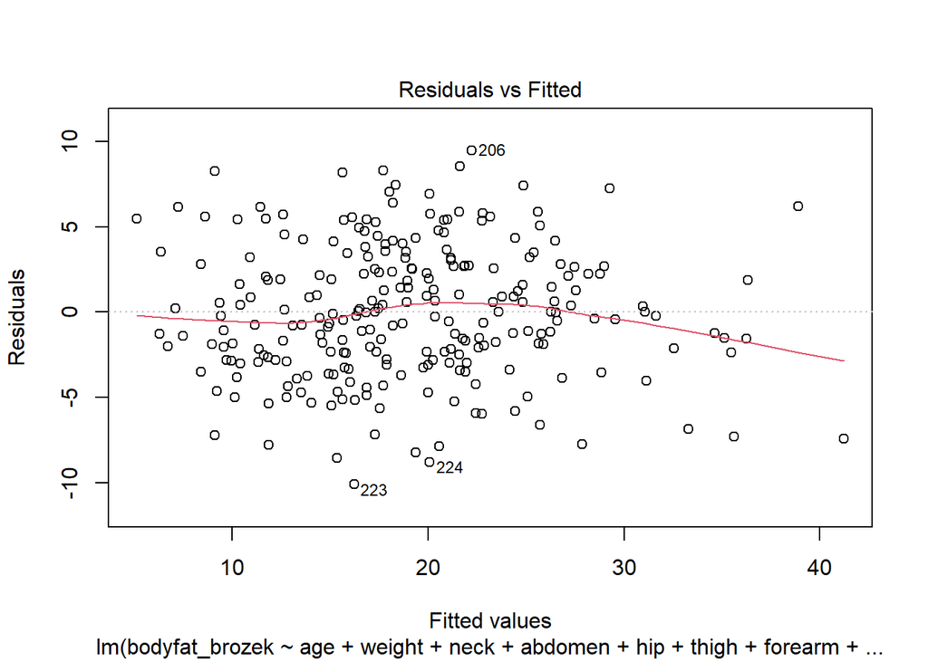

```r
plot(model_1, which = 1)
```

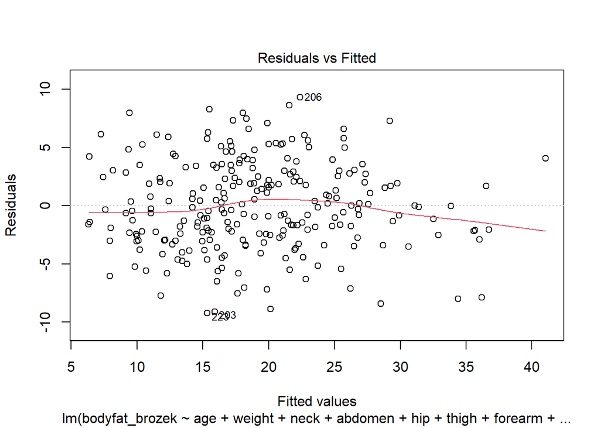

```r
plot(model_2, which = 1)
```

Horizontal bands around 0 are formed, indicating no heteroscedasticity and outliers were detected.

### Normal QQ plot

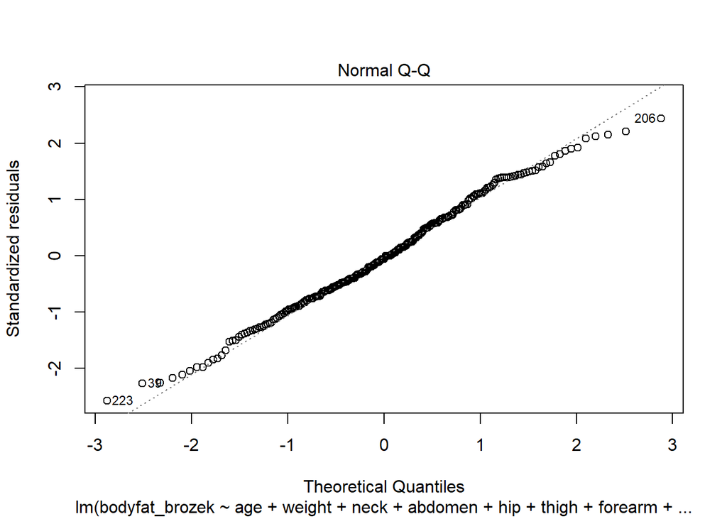

```r
plot(model_1, which = 2)
```

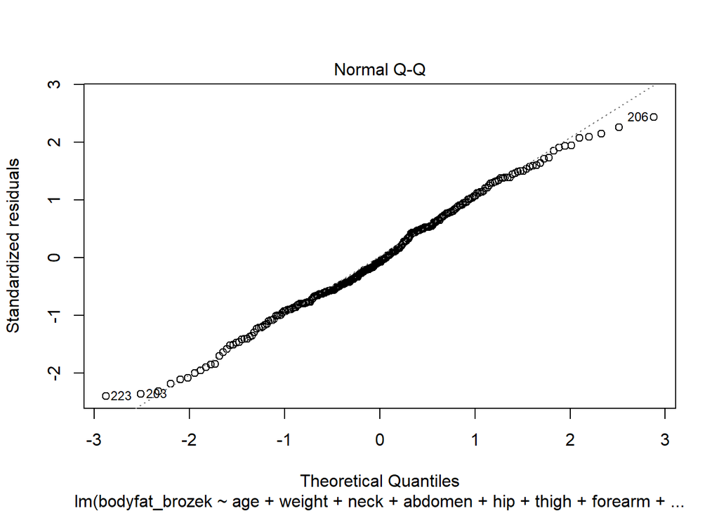

```r
plot(model_2, which = 2)
```

Straight lines were observed, indicating the residuals are normal.

### Scale-Location plot

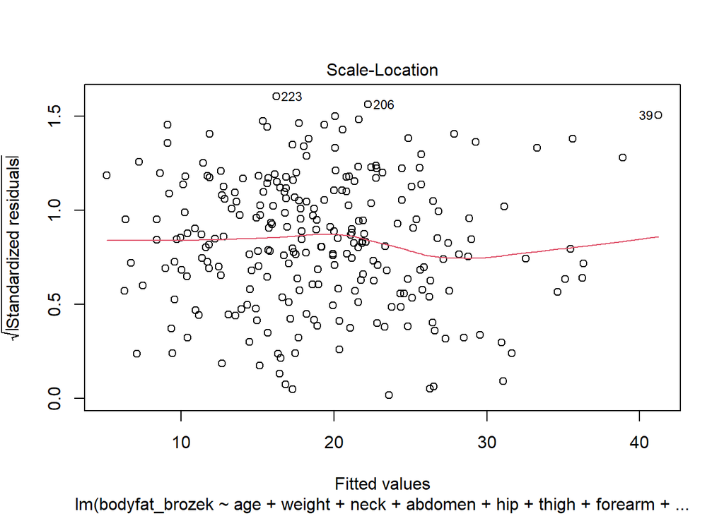

```r
plot(model_1, which = 3)
```

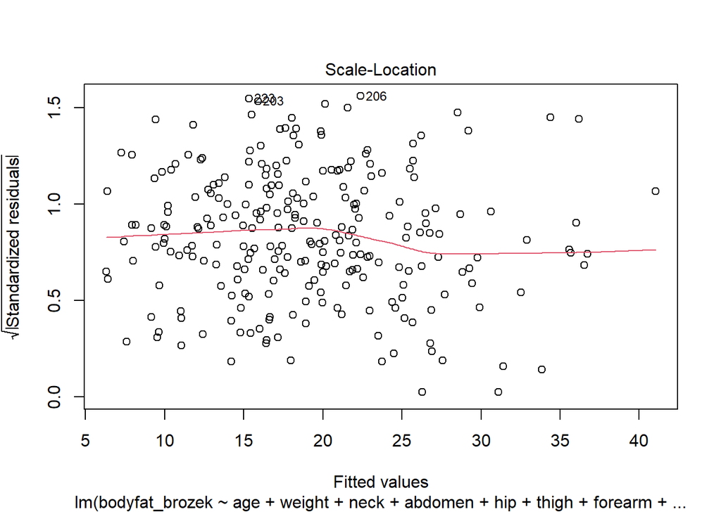

```r
plot(model_2, which = 3)
```

In each plot, the points were equally distributed with a horizontal line.

### Outliers and Leverage

Cook’s distance plot.

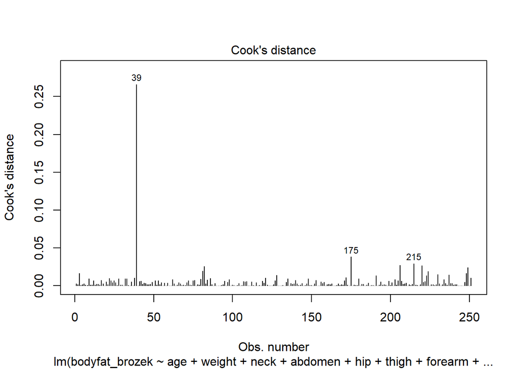

```r
plot(model_1, which = 4)  #39, #175, #216
```

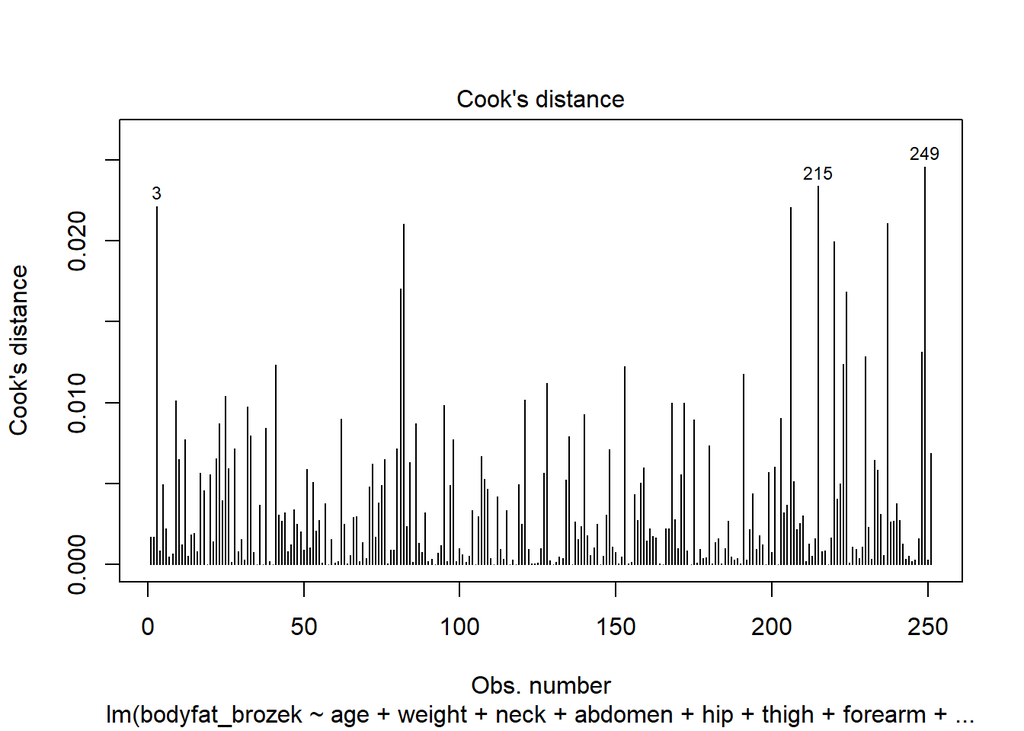

```r
plot(model_2, which = 4)  #3, #216, #250
```

There are in total 251 samples used to build our models, so the rule of thumb for Cook’s distance is D > 4/n = 0.016. There were some influential outliers were detected. Further process of outliers are required.

Let’s remove the influential points.

```r
bodyfat_out_1 = bodyfat_selected[-c(39,175,216),]
bodyfat_out_2 = bodyfat_selected[-c(3,216,250),]
```

Then, let’s fit the model with and without influential points. **Check model_1**

```r
with1 = lm(bodyfat_brozek ~ age + weight + neck + abdomen + hip + thigh + forearm + wrist, data = bodyfat_selected)

without1 = lm(bodyfat_brozek ~ age + weight + neck + abdomen + hip + thigh + forearm + wrist, data = bodyfat_out_1)

summary(with1)
```

```
##
## Call:
## lm(formula = bodyfat_brozek ~ age + weight + neck + abdomen +
##     hip + thigh + forearm + wrist, data = bodyfat_selected)
##
## Residuals:
##     Min      1Q  Median      3Q     Max
## -10.117  -2.800  -0.223   2.709   9.477
##
## Coefficients:
##              Estimate Std. Error t value Pr(>|t|)
## (Intercept) -19.00338   10.86380  -1.749  0.08152 .
## age           0.05827    0.02847   2.047  0.04175 *
## weight       -0.08266    0.03692  -2.239  0.02607 *
## neck         -0.42436    0.20780  -2.042  0.04222 *
## abdomen       0.87429    0.06656  13.136  < 2e-16 ***
## hip          -0.18514    0.12805  -1.446  0.14952
## thigh         0.27507    0.11966   2.299  0.02237 *
## forearm       0.47002    0.17257   2.724  0.00693 **
## wrist        -1.42508    0.47132  -3.024  0.00277 **
## ---
## Signif. codes:  0 '***' 0.001 '**' 0.01 '*' 0.05 '.' 0.1 ' ' 1
##
## Residual standard error: 3.96 on 242 degrees of freedom
## Multiple R-squared:  0.7422, Adjusted R-squared:  0.7337
## F-statistic:  87.1 on 8 and 242 DF,  p-value: < 2.2e-16
```

```r
summary(without1)
```

```
##
## Call:
## lm(formula = bodyfat_brozek ~ age + weight + neck + abdomen +
##     hip + thigh + forearm + wrist, data = bodyfat_out_1)
##
## Residuals:
##     Min      1Q  Median      3Q     Max
## -9.9050 -2.6794 -0.3214  2.6927  9.4414
##
## Coefficients:
##              Estimate Std. Error t value Pr(>|t|)
## (Intercept) -19.72718   10.84731  -1.819 0.070220 .
## age           0.06484    0.02866   2.262 0.024580 *
## weight       -0.07015    0.03709  -1.891 0.059803 .
## neck         -0.34600    0.21220  -1.631 0.104301
## abdomen       0.84556    0.06779  12.473  < 2e-16 ***
## hip          -0.13902    0.13099  -1.061 0.289622
## thigh         0.25536    0.11955   2.136 0.033702 *
## forearm       0.39693    0.20854   1.903 0.058188 .
## wrist        -1.61427    0.48206  -3.349 0.000943 ***
## ---
## Signif. codes:  0 '***' 0.001 '**' 0.01 '*' 0.05 '.' 0.1 ' ' 1
##
## Residual standard error: 3.937 on 239 degrees of freedom
## Multiple R-squared:  0.7435, Adjusted R-squared:  0.7349
## F-statistic: 86.58 on 8 and 239 DF,  p-value: < 2.2e-16
```

check without1 diagnostics

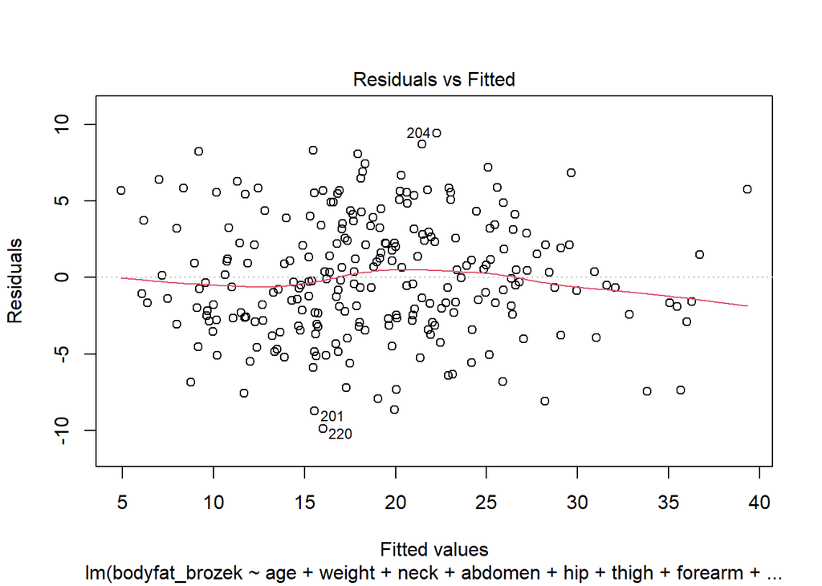

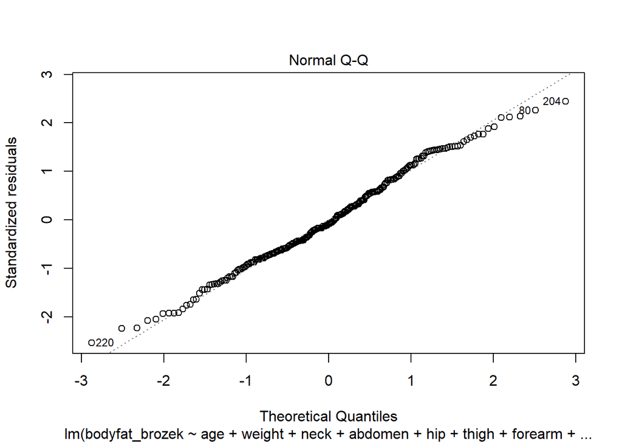

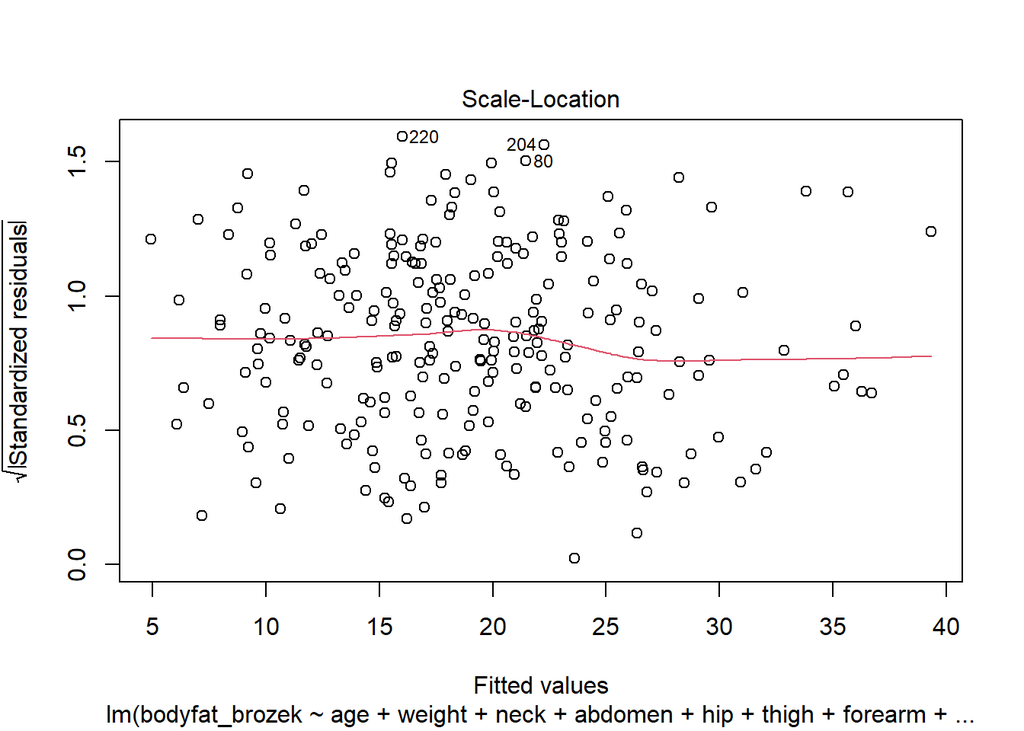

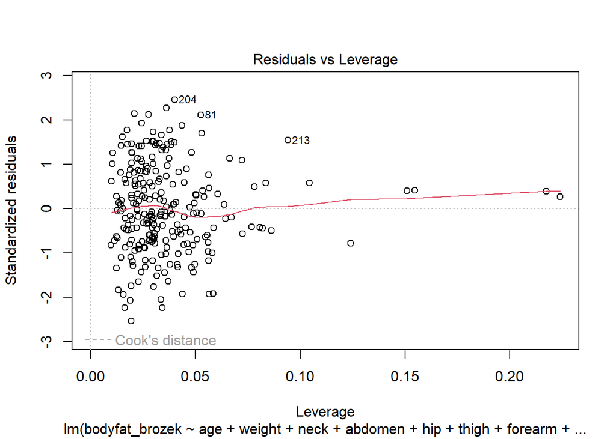

```r
plot(without1)
```

check model 2

```r
with2 = lm(bodyfat_brozek ~ age + weight + neck + abdomen + hip + thigh + forearm + wrist + weight*neck + neck*abdomen, data = bodyfat_selected)

without2 = lm(bodyfat_brozek ~ age + weight + neck + abdomen + hip + thigh + forearm + wrist + weight*neck + neck*abdomen, data = bodyfat_out_2)

summary(with2)
```

```
##
## Call:
## lm(formula = bodyfat_brozek ~ age + weight + neck + abdomen +
##     hip + thigh + forearm + wrist + weight * neck + neck * abdomen,
##     data = bodyfat_selected)
##
## Residuals:
##     Min      1Q  Median      3Q     Max
## -9.2337 -2.5363 -0.2964  2.7402  9.3143
##
## Coefficients:
##               Estimate Std. Error t value Pr(>|t|)
## (Intercept)  13.845207  39.141311   0.354 0.723857
## age           0.065526   0.028145   2.328 0.020735 *
## weight        0.641405   0.306566   2.092 0.037469 *
## neck         -1.155900   1.004728  -1.150 0.251099
## abdomen      -0.860353   0.957353  -0.899 0.369724
## hip          -0.150543   0.127789  -1.178 0.239941
## thigh         0.271825   0.120088   2.264 0.024496 *
## forearm       0.292488   0.181441   1.612 0.108270
## wrist        -1.607618   0.467833  -3.436 0.000695 ***
## weight:neck  -0.018230   0.007826  -2.329 0.020678 *
## neck:abdomen  0.044050   0.024734   1.781 0.076179 .
## ---
## Signif. codes:  0 '***' 0.001 '**' 0.01 '*' 0.05 '.' 0.1 ' ' 1
##
## Residual standard error: 3.898 on 240 degrees of freedom
## Multiple R-squared:  0.7522, Adjusted R-squared:  0.7419
## F-statistic: 72.86 on 10 and 240 DF,  p-value: < 2.2e-16
```

```r
summary(without2)
```

```
##
## Call:
## lm(formula = bodyfat_brozek ~ age + weight + neck + abdomen +
##     hip + thigh + forearm + wrist + weight * neck + neck * abdomen,
##     data = bodyfat_out_2)
##
## Residuals:
##     Min      1Q  Median      3Q     Max
## -9.1282 -2.4949 -0.2874  2.8912  9.3663
##
## Coefficients:
##               Estimate Std. Error t value Pr(>|t|)
## (Intercept)  19.853295  39.208651   0.506 0.613082
## age           0.071342   0.028341   2.517 0.012489 *
## weight        0.705852   0.307935   2.292 0.022771 *
## neck         -1.286374   1.006519  -1.278 0.202485
## abdomen      -1.049332   0.961528  -1.091 0.276242
## hip          -0.167534   0.128919  -1.300 0.195027
## thigh         0.275772   0.119969   2.299 0.022394 *
## forearm       0.314021   0.181339   1.732 0.084633 .
## wrist        -1.639190   0.469204  -3.494 0.000569 ***
## weight:neck  -0.019748   0.007855  -2.514 0.012599 *
## neck:abdomen  0.048699   0.024823   1.962 0.050948 .
## ---
## Signif. codes:  0 '***' 0.001 '**' 0.01 '*' 0.05 '.' 0.1 ' ' 1
##
## Residual standard error: 3.889 on 237 degrees of freedom
## Multiple R-squared:  0.7548, Adjusted R-squared:  0.7445
## F-statistic: 72.96 on 10 and 237 DF,  p-value: < 2.2e-16
```

check without2 diagnostics

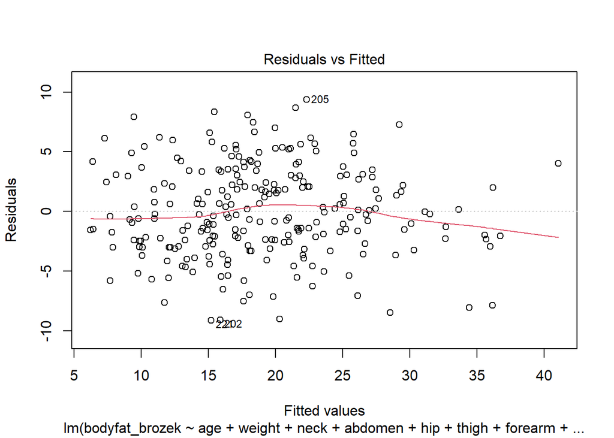

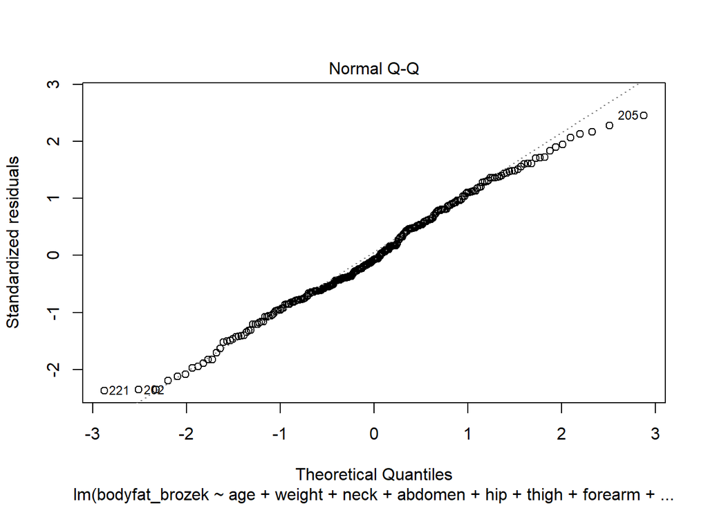

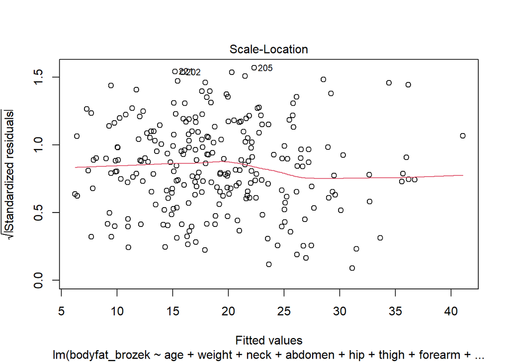

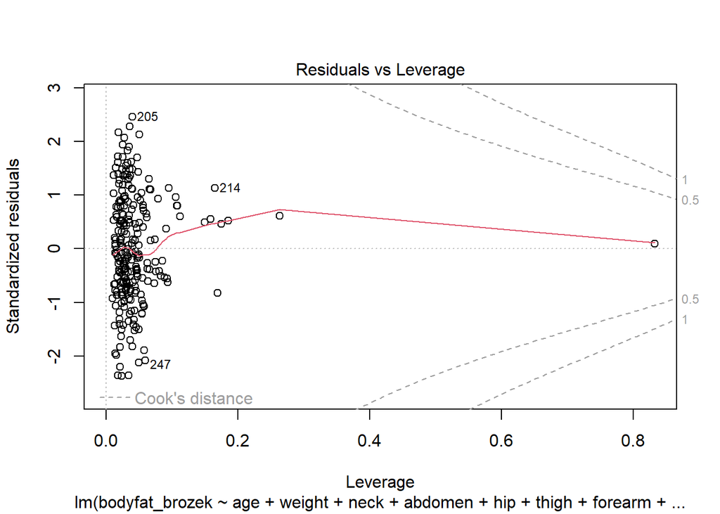

```r
plot(without2)
```

Both plots without influential point showed to better than those with influential points.

### Assessing Multicollinearility

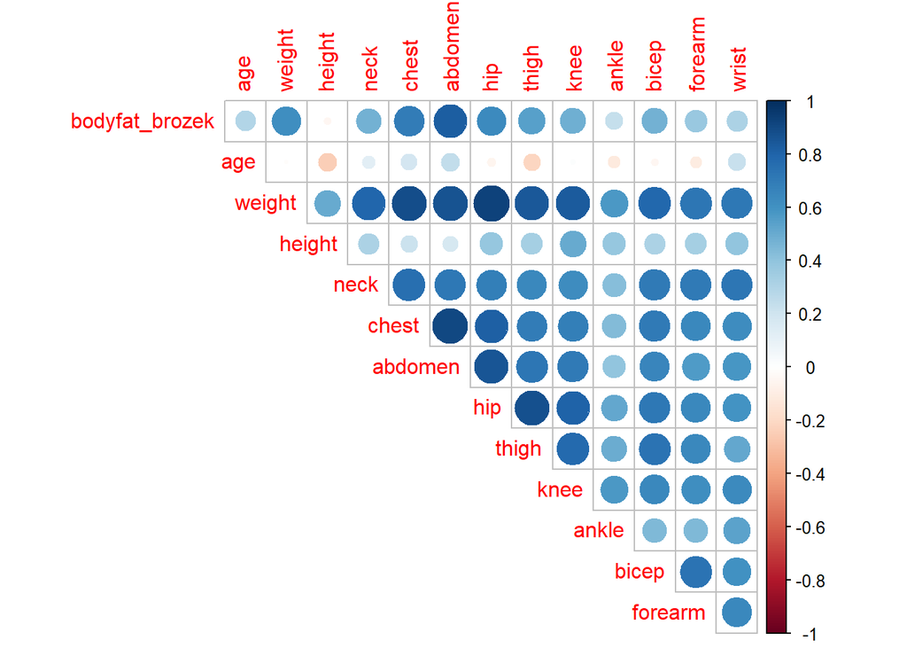

```r
corrplot(cor(bodyfat_out_1), type = "upper", diag = FALSE)
```

Let’s check the model without interactions terms.

```r
check_collinearity(without1)
```

[output not shown]

It’s found that, there VIF value is very high for weight, hip and abdomen terms, indicating their strong correlation with other variables.

Let’s remove the weight term with highest VIF(15.62).

```r
without1_new = lm(bodyfat_brozek ~ age + neck + abdomen + hip + thigh + forearm + wrist, data = bodyfat_out_1)
check_collinearity(without1_new)
```

[output not shown]

The correlation between the variables is lowered, but we still have hip(8.64), thigh(5.37) and abdomen(6.21) with high VIF. Then we remove the hip term.

```r
without1_new_2 = lm(bodyfat_brozek ~ age  + neck + abdomen + thigh + forearm + wrist, data = bodyfat_out_1)
check_collinearity(without1_new_2)
```

```
## # Check for Multicollinearity
##
## Low Correlation
##
##     Term  VIF   VIF 95% CI Increased SE Tolerance Tolerance 95% CI
##      age 1.86 [1.59, 2.25]         1.36      0.54     [0.44, 0.63]
##     neck 3.33 [2.74, 4.12]         1.83      0.30     [0.24, 0.36]
##  abdomen 3.82 [3.12, 4.73]         1.95      0.26     [0.21, 0.32]
##    thigh 3.74 [3.07, 4.64]         1.93      0.27     [0.22, 0.33]
##  forearm 2.57 [2.14, 3.15]         1.60      0.39     [0.32, 0.47]
##    wrist 2.54 [2.12, 3.11]         1.59      0.39     [0.32, 0.47]
```

After removing these two variables, we have got all predictors with low VIF.

The final model we will have with and without interaction would be.

```r
model_1f = lm(bodyfat_brozek ~ age  + neck + abdomen + thigh + forearm + wrist, data = bodyfat_out_1)
summary(model_1f)
```

```
##
## Call:
## lm(formula = bodyfat_brozek ~ age + neck + abdomen + thigh +
##     forearm + wrist, data = bodyfat_out_1)
##
## Residuals:
##     Min      1Q  Median      3Q     Max
## -9.7338 -2.7938 -0.1265  2.7111 10.0812
##
## Coefficients:
##             Estimate Std. Error t value Pr(>|t|)
## (Intercept) -9.77652    5.56083  -1.758 0.079999 .
## age          0.09324    0.02729   3.416 0.000745 ***
## neck        -0.41559    0.20453  -2.032 0.043258 *
## abdomen      0.70680    0.04914  14.383  < 2e-16 ***
## thigh        0.09021    0.10085   0.894 0.371962
## forearm      0.30520    0.20829   1.465 0.144155
## wrist       -2.14698    0.44709  -4.802 2.76e-06 ***
## ---
## Signif. codes:  0 '***' 0.001 '**' 0.01 '*' 0.05 '.' 0.1 ' ' 1
##
## Residual standard error: 3.991 on 241 degrees of freedom
## Multiple R-squared:  0.7342, Adjusted R-squared:  0.7276
## F-statistic:   111 on 6 and 241 DF,  p-value: < 2.2e-16
```

```r
model_2f = lm(bodyfat_brozek ~ age  + neck + abdomen + thigh + forearm + wrist + neck*abdomen, data = bodyfat_out_2)
summary(model_2f)
```

```
##
## Call:
## lm(formula = bodyfat_brozek ~ age + neck + abdomen + thigh +
##     forearm + wrist + neck * abdomen, data = bodyfat_out_2)
##
## Residuals:
##     Min      1Q  Median      3Q     Max
## -9.8236 -2.7998 -0.2458  2.5657  9.9140
##
## Coefficients:
##                Estimate Std. Error t value Pr(>|t|)
## (Intercept)  -72.677880  20.896807  -3.478  0.00060 ***
## age            0.090281   0.027192   3.320  0.00104 **
## neck           1.225430   0.581292   2.108  0.03606 *
## abdomen        1.393665   0.223466   6.237 2.00e-09 ***
## thigh          0.062708   0.099650   0.629  0.52976
## forearm        0.300439   0.180493   1.665  0.09731 .
## wrist         -2.053941   0.436674  -4.704 4.32e-06 ***
## neck:abdomen  -0.017789   0.005543  -3.209  0.00151 **
## ---
## Signif. codes:  0 '***' 0.001 '**' 0.01 '*' 0.05 '.' 0.1 ' ' 1
##
## Residual standard error: 3.982 on 240 degrees of freedom
## Multiple R-squared:  0.7398, Adjusted R-squared:  0.7322
## F-statistic: 97.46 on 7 and 240 DF,  p-value: < 2.2e-16
```

## Cross validation

Let’s create RMSE distribution boxplot

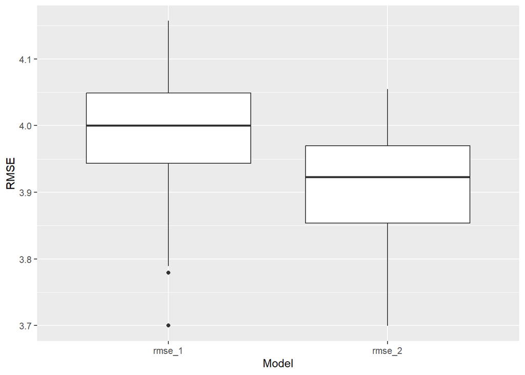

```r
set.seed(1)
cv_df = crossv_mc(bodyfat_selected, 100) %>%
  mutate(train = map(train, as_tibble),
         test = map(test, as_tibble)) %>%
  mutate(
    mod_1 = map(.x = train, ~lm(bodyfat_brozek ~ age  + neck + abdomen + thigh + forearm + wrist, data =.x)),
    mod_2 = map(.x = train, ~lm(bodyfat_brozek ~ age  + neck + abdomen + thigh + forearm + wrist + neck*abdomen, data =.x))
  ) %>%
  mutate(
    rmse_1 = map2_dbl(.x = mod_1, .y = test, ~rmse(model = .x)),
    rmse_2 = map2_dbl(.x = mod_2, .y = test, ~rmse(model = .x))
  )

rmse_boxplot = cv_df %>%
  dplyr::select(rmse_1, rmse_2) %>%
  pivot_longer(rmse_1:rmse_2,
               names_to = "model",
               values_to = "rmse",
               names_prefix = "remse_") %>%
  ggplot(aes(x = model, y = rmse)) + geom_boxplot() +
  labs(x = "Model", y = "RMSE")

rmse_boxplot
```

By plotting the RMSE distribution of two model, we can find that the interaction model has the lower RMSE, which is more prefered.

```r
set.seed(1)
train = trainControl(method = "cv", number = 10)

mod_1_cv = train(bodyfat_brozek ~ age  + neck + abdomen + thigh + forearm + wrist, data = bodyfat_out_1, trControl = train, method = "lm", na.action = na.pass)

mod_2_cv = train(bodyfat_brozek ~ age  + neck + abdomen + thigh + forearm + wrist + neck*abdomen, data = bodyfat_out_2, trControl = train, method = "lm", na.action = na.pass)

RMSE = bind_rows(
  as_tibble(mod_1_cv$results),
  as_tibble(mod_2_cv$results)
)
RMSE %>%
  knitr::kable(digit = 3)
```

| intercept | RMSE | Rsquared | MAE | RMSESD | RsquaredSD | MAESD |
| --- | --- | --- | --- | --- | --- | --- |
| TRUE | 4.019 | 0.732 | 3.289 | 0.329 | 0.068 | 0.254 |
| TRUE | 3.989 | 0.736 | 3.268 | 0.563 | 0.056 | 0.590 |

Model 2’s RMSE(3.989) is slightly smaller than that of model 1(4.019).

Finally, based on the data analysis, the final model we would choose to is the model 2 with interactions terms.

The final model would be bodyfat_brozek = -72.7 + 0.090*age + 1.23*neck + 1.39*abdomen + 0.0627*thigh + 0.300*forearm -2.05*wrist - 0.0178*neck:abdomen

```r
final_model = lm(bodyfat_brozek ~ age  + neck + abdomen + thigh + forearm + wrist + neck*abdomen, data = bodyfat_out_2)
summary(final_model)
```

```
##
## Call:
## lm(formula = bodyfat_brozek ~ age + neck + abdomen + thigh +
##     forearm + wrist + neck * abdomen, data = bodyfat_out_2)
##
## Residuals:
##     Min      1Q  Median      3Q     Max
## -9.8236 -2.7998 -0.2458  2.5657  9.9140
##
## Coefficients:
##                Estimate Std. Error t value Pr(>|t|)
## (Intercept)  -72.677880  20.896807  -3.478  0.00060 ***
## age            0.090281   0.027192   3.320  0.00104 **
## neck           1.225430   0.581292   2.108  0.03606 *
## abdomen        1.393665   0.223466   6.237 2.00e-09 ***
## thigh          0.062708   0.099650   0.629  0.52976
## forearm        0.300439   0.180493   1.665  0.09731 .
## wrist         -2.053941   0.436674  -4.704 4.32e-06 ***
## neck:abdomen  -0.017789   0.005543  -3.209  0.00151 **
## ---
## Signif. codes:  0 '***' 0.001 '**' 0.01 '*' 0.05 '.' 0.1 ' ' 1
##
## Residual standard error: 3.982 on 240 degrees of freedom
## Multiple R-squared:  0.7398, Adjusted R-squared:  0.7322
## F-statistic: 97.46 on 7 and 240 DF,  p-value: < 2.2e-16
```

```r
table_2= data.frame(broom::tidy(summary(final_model)))
table_2 %>%
  knitr::kable(digit = 3)
```

| term | estimate | std.error | statistic | p.value |
| --- | --- | --- | --- | --- |
| (Intercept) | -72.678 | 20.897 | -3.478 | 0.001 |
| age | 0.090 | 0.027 | 3.320 | 0.001 |
| neck | 1.225 | 0.581 | 2.108 | 0.036 |
| abdomen | 1.394 | 0.223 | 6.237 | 0.000 |
| thigh | 0.063 | 0.100 | 0.629 | 0.530 |
| forearm | 0.300 | 0.180 | 1.665 | 0.097 |
| wrist | -2.054 | 0.437 | -4.704 | 0.000 |
| neck:abdomen | -0.018 | 0.006 | -3.209 | 0.002 |